# Week 0: Intro to C++ · CS112

[figure not shown]

CS 112

Introduction to Data Structures

Week 0

Intro to C++

Eric Araújo

Calvin University · Fall 2026

## This Week

- 1

  Structure of a C++ program
- 2

  Compilation pipeline
- 3

  Types, variables, I/O
- 4

  Functions
- 5

  Pointers KEY
- 6

  Arrays
- 7

  C++ vs. Python

## Your First C++ Program

```cpp
int main() {


    return 0;
}
```

Every C++ program execution begins at `main()`.

## Your First C++ Program

```cpp
#include <iostream>
using namespace std;

int main() {
    cout << "Hello, World!" << endl;
    return 0;
}
```

This is a full C++ program, with `#include`, `namespace`, and our `main()` function.

## Anatomy of a C++ Program

```cpp
#include <iostream>
using namespace std;

int main() {
    cout << "Hello, World!" << endl;
    return 0;
}
```

1

`#include <iostream>`

Pulls in the I/O library, C++'s version of `import`.

2

`using namespace std;`

Lets you write `cout` instead of `std::cout`.

5

`cout << … << endl;`

Prints to the terminal. `<<` is the “injection” operator. `endl` ends the line *and* flushes the buffer, so the text appears immediately.

6

`return 0;`

Tells the OS the program finished cleanly.

## Compilation Pipeline

[figure not shown]

Compile-time error

error: 'cout' was not declared in this scope

One file didn't make sense on its own: a typo, a missing `#include`, a type mismatch.

Link-time error

undefined reference to `helper()'

Every file compiled fine, but a function was *declared* and never *defined*.

## Headers and Translation Units

header `.h`

**Declarations**: what exists and how to call it. Shared by many `.cpp` files, and never compiled on its own.

translation unit `.cpp`

One `.cpp` *after* its headers have been pasted in. This is what the compiler actually reads, and it becomes exactly one `.o`.

[figure not shown]

Unlike Python, you *must* compile before running.  
**Upside**: a whole class of bugs is caught at compile time, not in production.

# Demo

Live coding. What could possibly go wrong?

(the semicolon is always missing on line 12)

Talk to your neighbor · TTYN

**What does a compiler do?**

- A. Create an executable program from source code.
- B. Check the source code for errors.
- C. Pull in required libraries.
- D. A and B only.
- E. B and C only.
- F. A, B, and C.
- G. None of the above.

✓ Answer

**F. All three.** The compiler translates code (A), catches type errors (B), and processes `#include` directives to pull in library declarations (C).

## Data Types & Sizes

[figure not shown]

whole numbers real numbers single values grows as needed

```cpp
cout << sizeof(int);      // 4: check any type yourself
cout << sizeof(double);   // 8
cout << sizeof(grade);    // 1: works on variables too
```

Types are **fixed at compile time**.  
Sizes can vary by machine, `sizeof` tells you the truth on yours.  
A `string` keeps its characters on the **heap**, memory the program asks for while it runs. More on that in week 4.

## Python vs. C++: Variables

### Python

```python
x = 7
```

### C++

```cpp
int x = 7;
```

Both look like "a variable called x holding 7".  
In C++ that box lives on the **stack**, inside the *stack frame* belonging to this call of `main()`. Watch what happens when we assign `x = 3.14`.

## The Same Variable, Reassigned

### Python

```python
x = 3.14
```

### C++

```cpp
x = 3.14;
```

Python moves the label: `x` points at a *new* float object, and the `int 7` is abandoned.  
C++ keeps the box: same address, still an `int`, so 3.14 is truncated to **3**.

## Declare, Then Initialize

```cpp
...
int    count;             // declared: NOT initialized
int    total  = 0;        // declared and initialized
double pi     = 3.14159;
char   grade  = 'A';
bool   ready  = true;
string name   = "Ada";

cout << "count: " << count << endl;   // ⚠️ undefined: could print anything
cout << "total: " << total << endl;   // always 0
...
```

$ ./init_demo

count: -8593204whatever those bytes happened to hold

total: 0exactly what you put there

$ ./init_demosame program, run again

count: 32764different garbage this time

total: 0

In Python a name doesn't exist until you assign to it.  
In C++ the box exists the moment you *declare* it, holding whatever the last program left in that memory.

Talk to your neighbor · TTYN

**Will this C++ code compile?**

```cpp
int x = 11;
x = "12";
```

- A. Yes
- B. No
- C. Yes, but with warnings.

✓ Answer

**B. No.** `x` was declared as `int`. Assigning a string literal to it is a type error; the compiler rejects it.

## Using `const`

```cpp
const int    MAX_SIZE = 100;
const double PI       = 3.14159265;

MAX_SIZE = 200;  // ❌ compiler error: read-only!
```

- Put `const` before the type to make a variable read-only
- The compiler **rejects** any code that tries to change it
- Convention: use `ALL_CAPS` names for constants

Use `const` liberally; it documents intent and catches bugs at compile time.

## Input / Output

```cpp
#include <iostream>
using namespace std;

int main() {
    double value;
    cout << "Enter a number: ";   // output → terminal
    cin  >> value;                // input  ← terminal
    cerr << "got " << value << endl; // error stream

    cout << "You entered: " << value << endl;
    return 0;
}
```

`cout` + `<<`: **injection**  
output to the terminal

`cin` + `>>`: **extraction**  
input from the terminal

## Streams

[figure not shown]

A stream is a **one-way sequence of characters**, not a function call. `cin` flows in, `cout` and `cerr` flow out.  
Swap the keyboard for a file and the picture does not change: that is `ifstream`, and it is the next slide.

## File I/O

```cpp
#include <iostream>
#include <fstream>    // ifstream reads a file, ofstream writes one
#include <cmath>      // sqrt
#include <cassert>
using namespace std;

int main() {
    ifstream fin("numbers.txt");  // open the file, attach a stream to it
    assert(fin.is_open());        // a missing file is not an error to ignore

    double n;                     // ONE variable, reused for every number
    while (fin >> n) {            // read the next number; false when none left
        cout << sqrt(n) << endl;  // fin has already moved past that number
    }

    fin.close();                  // hand the file back to the OS
    return 0;
}
```

`ifstream` reads from a file exactly like `cin` reads from the terminal.  
The loop ends on its own, because `fin >> n` is false once the file runs out.

## What `fin >> n` Actually Does

[figure not shown]

The data never leaves the file: `fin` is a **read head** parked in it. Every `>>` converts the next characters into a `double` and drags that head forward.  
`<<` runs the other way, and does not care where it is pointed: `cout` for the screen, an `ofstream` for a file.

## Decimal, Binary, Hexadecimal

```cpp
int x = 33;        // decimal  (default)
int y = 0x21;      // hex:    2×16 + 1 = 33
int z = 0b100001;  // binary: 1×32 + 1 = 33

cout << x << " " << y << " " << z << endl;
// Output:  33 33 33
```

- `0x` prefix → hexadecimal (base 16)
- `0b` prefix → binary (base 2)
- Memory addresses are typically displayed in hex

Three ways to write the *same number*. The compiler stores them identically in memory.

## Meet Rocky

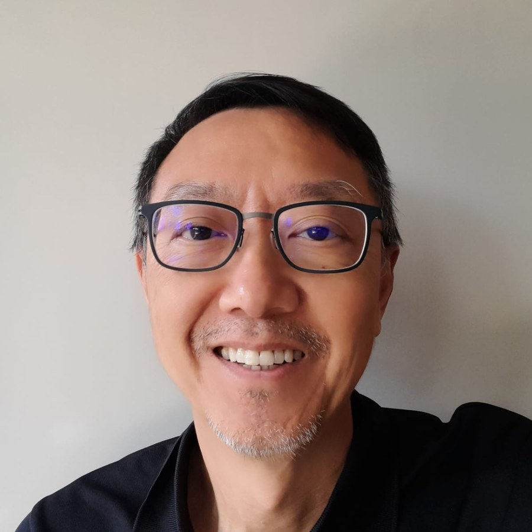

Not this Rocky.

Prof. Rocky Chang, our department

[figure not shown]

THIS Rocky!

Rocky, an Eridian, from *Project Hail Mary*

## Why Ten?

[figure not shown]

Three limbs down, two up: two hands of three fingers, so he counts in sixes.

[figure not shown]

Ten is an accident of anatomy: we have ten fingers.  
Rocky stands on three of his five limbs, leaving two hands of three fingers, so Eridians count in **sixes**: their "10" is our 6.  
A wire is either on or off, so computers count in **twos**, and hex packs four of those bits into one digit.

## Why bother with binary?

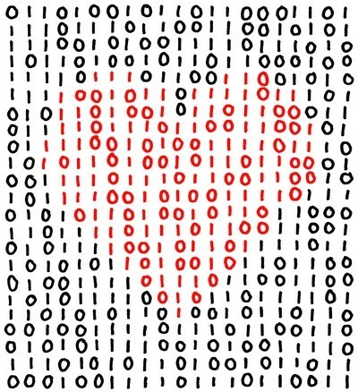

Everything on the machine is bits. Hex is just a friendlier way to read them.

xkcd #99 · xkcd.com · CC BY-NC 2.5

## Functions

Write the tests *before* the function; it forces you to think about what it should do:

```cpp
assert(factorial(0) == 1);
assert(factorial(1) == 1);
assert(factorial(4) == 24);
assert(factorial(5) == 120);
```

This test-first style is called **test-driven development**. Your assertions become the spec.

## Functions

```cpp
unsigned factorial(unsigned n) {
    unsigned result = 1;
    for (unsigned i = 2; i <= n; ++i) {
        result *= i;
    }
    return result;
}

int main() {
    assert(factorial(0) == 1);
    assert(factorial(1) == 1);
    assert(factorial(4) == 24);
    assert(factorial(5) == 120);
    cout << "All tests passed!" << endl;
    return 0;
}
```

## Pointers

Memory is a row of numbered boxes. A variable is one box.

```cpp
int y = 77;
```

`y` is the box at `0x1004`. The name is ours; the machine only knows the number.

## Pointers

`&` ("address-of") hands you the number of a box.

```cpp
int y  = 77;
int *x = &y;   // x holds the address of y
```

`x` is an ordinary box too. What makes it a pointer is *what it holds*: an address.  
The arrow is us drawing the same number twice. The machine just has `0x1004`.

## Pointers: Dereferencing

`*` means "go to that address".

```cpp
int y  = 77;
int *x = &y;

cout << x;    // 0x1004: the address itself
cout << *x;   // 77:     follow the arrow
*x = 99;      // write at the far end of the arrow
cout << y;    // 99:     y changed, without naming y
```

`x` and `*x` are different questions: *which box* versus *what is in it*.

Talk to your neighbor · TTYN

```cpp
int y = 77;    // placed at address 0x1004
int *x = &y;  // placed at address 0x1010
cout << x;
```

**What is printed?**

- A. 77
- B. 0x1004
- C. 0x1010
- D. Error

✓ Answer

**B. 0x1004.** `x` holds the address of `y`. Printing `x` (no dereference) prints that address.

Talk to your neighbor · TTYN

```cpp
int y = 77;
int *x = &y;
cout << *y;   // note: *y, not *x
```

**What is printed?**

- A. 77
- B. 0x12345678
- C. 0x1010
- D. Compile error

✓ Answer

**D. Compile error.** `y` is an `int`, not a pointer. You can't dereference a non-pointer.

Talk to your neighbor · TTYN

```cpp
int y = 77;
int *x = &y;
cout << *x;
```

**What is printed?**

- A. 77
- B. 0x12345678
- C. 0x1010
- D. Error

✓ Answer

**A. 77.** `*x` dereferences the pointer: follow the address stored in `x` to read the value there.

Talk to your neighbor · TTYN

```cpp
int y = 77;
int *x = &y;
*x = 78;
cout << *x;
```

**What is printed?**

- A. 77
- B. 78
- C. 0x1010
- D. Error

✓ Answer

**B. 78.** `*x = 78` writes 78 into the memory location that `x` points to. Dereferencing `x` now reads 78.

Talk to your neighbor · TTYN

```cpp
int y = 77;
int *x = &y;
*x = 78;
cout << y;    // note: y, not *x
```

**What is printed?**

- A. 77
- B. 78
- C. 0x1010
- D. Error

✓ Answer

**B. 78.** `x` points to `y`'s memory location, so writing through `*x` changed `y` itself.

## Ask a programmer for a few pointers

[figure not shown]

He *did* give him pointers. Three of them, and every one is a real address.

xkcd #138 · xkcd.com · CC BY-NC 2.5

## Arrays

Like Python lists, but **fixed size** and **no bounds checking**.

```cpp
char  letters[26];            // 26 chars, uninitialized
float scores[10] = { 0 };     // all 0.0
int   vals[] = { 10, 9, 4, 2, 0 };  // size inferred: 5
```

- Size must be known at compile time (for stack arrays)
- Indexes: `0` to `n−1`
- Accessing out of bounds → **undefined behavior**, no crash guaranteed

## Arrays: Memory Layout

```cpp
int arr[6] = { 1, 3, 5, 2, 77, -11 };
```

[figure not shown]

`arr` is a pointer to the first box, so `arr[i]` means "start at `arr`, step `i` ints along".  
That is why indexes start at **0**: the first element is zero steps from the start.

## Pointers & Arrays

```cpp
int arr[] = { 3, -11, 4, 12 };
int *ptr  = &arr[2];              // ptr points at arr[2]

cout << *ptr       << endl;      // this box
cout << *(ptr + 1) << endl;      // one int further along
cout << *(ptr - 1) << endl;      // one int back
```

$ ./ptr_demo

4arr[2], where ptr points

12arr[3], the next box

-11arr[1], the box before

`ptr + 1` does not add 1 to the address: it adds **one int**, so 4 bytes.  
That is exactly what `arr[i]` has been doing all along.

Talk to your neighbor · TTYN

```cpp
int arr[] = { 3, -11, 4, 12 };
int *ptr  = &arr[2];
cout << *ptr;
```

**What is printed?**

- A. 3
- B. 2
- C. 4
- D. -11

✓ Answer

**C. 4.** `ptr` points to `arr[2]`, which holds 4. Dereferencing it reads that value.

## C++ vs. Python: Core Differences

| Feature | Python | C++ |
| --- | --- | --- |
| Variables | Reference to a typed object | Named memory location with explicit type |
| Type checking | Dynamic (runtime) | Static (compile time) |
| Function return type | Implied from `return` | Declared explicitly |
| 1D data structure | `list` | `array` or `vector` |
| Memory management | Automatic (garbage collected) | Mostly explicit |
| Entry point | First line executed | `main()` |

## C++ vs. Python: More Differences

| Feature | Python | C++ |
| --- | --- | --- |
| Interface / impl split | Not explicit | `.h` header + `.cpp` source |
| Parameter passing | Pass-by-value (objects by ref) | By-value, by-reference, by-const-ref |
| Access control | Mostly none | `public` / `private` |
| Constructors | Called explicitly | Explicit *or implicit* (scope entry) |
| Destructors | None (GC handles it) | Defined; called implicitly at scope exit |
| Generics | None | Templates, powerful but complex |
| Strings | Built-in | `#include <string>` |

## Week 0 Recap

- C++ programs need a `main()` and must be **compiled** before running
- Types are **explicit and checked at compile time**
- Pointers hold **memory addresses**: the key concept in C++
- Arrays are contiguous memory blocks: fast, but no safety net
- C++ gives you more control than Python, and more responsibility

Next: Getting Started (pre-lab) · then a01: RPG Character Creator →

This deck stands on earlier CS112 materials by  
**Joel Adams** and **Victor Norman** · adapted and extended by **Eric Araújo**